# 제목: ADP 실기를 위한 시계열 검정 정리

# 지문만 보고 1초 만에 파악하는 시계열 검정(Time Series Testing) 완벽 가이드

**시계열 검정(Time Series Testing)**은 시계열 데이터가 예측 모형에 적합한 구조를 갖는지 확인하는 과정입니다. ADP 실기 시험에서는 특히 **정상성(Stationarity)** 여부를 판단하고, 필요하면 **차분(Differencing)** 을 수행한 뒤 **ACF/PACF**, **Ljung-Box 검정**까지 연결하는 흐름이 자주 등장합니다.

## 🎯 [핵심] ADP 지문 키워드로 보는 시계열 검정 선택 가이드

문제를 읽고 아래의 키워드에 따라 어떤 검정을 해야 하는지 판단하세요.

| 확인 포인트 | 무엇을 해야 하나? | ADP 지문 단골 키워드 (이렇게 문제에 나옵니다!) |
| --- | --- | --- |
| **정상성 확인** | 그래프 확인 + ADF 검정 | “**정상성 여부를 판단하시오**”, “**단위근 검정**을 수행하시오.” |
| **비정상 시계열 처리** | 차분 후 재검정 | “**차분 후 정상성을 확인하시오**”, “**1차 차분을 수행하시오**” |
| **모형 단서 확인** | ACF / PACF 해석 | “ACF와 PACF를 보고 모형을 설명하시오.” |
| **백색잡음 여부** | Ljung-Box 검정 | “잔차가 백색잡음인지 검정하시오.” |

> 💡 **실전 Tip:** * 시계열 검정 문제는 대부분 **원시계열 -> ADF -> 차분 -> ADF 재검정** 흐름으로 갑니다. * 정상성이 없으면 ARIMA류 모형을 바로 적용하기 어렵습니다. * ACF/PACF는 숫자를 외우기보다 **느리게 감소하는지 / 특정 시차에서 끊기는지**를 보는 것이 핵심입니다.

시계열 검정은 단순히 p-value 하나만 보는 문제가 아닙니다. **그래프 모양, 차분 전후 변화, 자기상관 구조**를 함께 해석해야 실제 시험 답안이 깔끔하게 완성됩니다.

## 1. 정상성 개념과 원시 시계열 확인

정상성이란 시간에 따라 평균과 분산, 자기공분산 구조가 크게 변하지 않는 상태를 의미합니다. 추세가 강하거나 수준(level)이 계속 변하는 시계열은 보통 비정상 시계열로 판단합니다.

- **상황:** 일별 관측된 시계열 데이터가 주어졌다. 먼저 원시 시계열 그래프를 통해 정상성 여부를 시각적으로 판단하시오.

### 🐍 Python 코드

```python
import pandas as pd
import matplotlib.pyplot as plt

# 1. GitHub Raw URL에서 데이터 불러오기
url = "https://raw.githubusercontent.com/MOON001208/ADP-data-set-and-analysis/main/adp_study/data/timeseries_stationarity_daily.csv"
df = pd.read_csv(url)

# 2. 날짜형 변환 및 정렬
df['date'] = pd.to_datetime(df['date'])
df = df.sort_values('date')

# 3. 원시 시계열 그래프
plt.figure(figsize=(10, 4))
plt.plot(df['date'], df['value'], marker='o')
plt.title("Original Time Series")
plt.xlabel("Date")
plt.ylabel("Value")
plt.xticks(rotation=45)
```

```
(array([20089., 20103., 20120., 20134., 20148., 20162.]), [Text(0, 0, ''), Text(0, 0, ''), Text(0, 0, ''), Text(0, 0, ''), Text(0, 0, ''), Text(0, 0, '')])
```

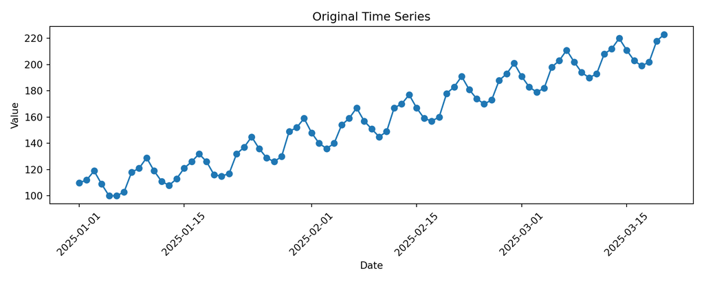

```python
plt.tight_layout()
plt.show()
```

### 📊 R 코드

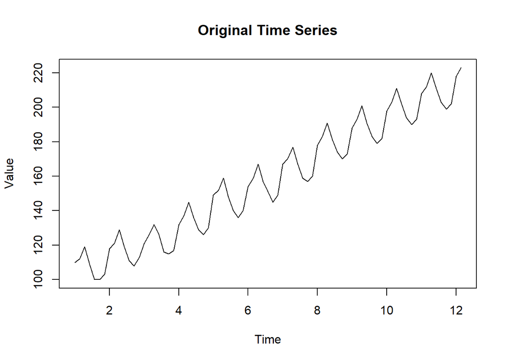

```r
# 1. GitHub Raw URL에서 데이터 불러오기
url <- "https://raw.githubusercontent.com/MOON001208/ADP-data-set-and-analysis/main/adp_study/data/timeseries_stationarity_daily.csv"
df <- read.csv(url)

# 2. 날짜형 변환 및 정렬
df$date <- as.Date(df$date)
df <- df[order(df$date), ]

# 3. 시계열 객체 생성 및 그래프 출력
x <- ts(df$value, frequency = 7)
plot(x, main = "Original Time Series", ylab = "Value", xlab = "Time")
```

### 📝 [결론 해석 모범 답안 작성법]

> 원시 시계열 그래프를 확인한 결과 시간이 지남에 따라 전체 수준이 점차 상승하는 경향이 나타난다. 따라서 평균 수준이 일정하지 않은 비정상 시계열일 가능성이 높으며, 단위근 검정을 통해 정상성 여부를 추가로 확인할 필요가 있다.

## 2. ADF 검정으로 정상성 판단하기

시계열 정상성 검정에서 가장 대표적으로 사용하는 방법이 **ADF(Augmented Dickey-Fuller) 검정**입니다.

- **가설:**
  - $H_0$ (귀무가설): 단위근이 존재한다. 즉, 시계열은 비정상이다.
  - $H_1$ (대립가설): 단위근이 존재하지 않는다. 즉, 시계열은 정상이다.

### 🐍 Python 코드

```python
import pandas as pd
from statsmodels.tsa.stattools import adfuller

# 1. 데이터 불러오기
url = "https://raw.githubusercontent.com/MOON001208/ADP-data-set-and-analysis/main/adp_study/data/timeseries_stationarity_daily.csv"
df = pd.read_csv(url)
df['date'] = pd.to_datetime(df['date'])
df = df.sort_values('date')

# 2. ADF 검정
# statsmodels와 tseries는 lag 선택 방식, 회귀식 옵션, p-value 근사 방식이 달라
# 같은 데이터라도 통계량과 p-value가 완전히 같지 않을 수 있습니다.
adf_result = adfuller(df['value'])
print(f"[ADF 통계량] {adf_result[0]:.4f}")
```

```
[ADF 통계량] 0.5680
```

```python
print(f"[ADF 검정 p-value] {adf_result[1]:.4f}")
```

```
[ADF 검정 p-value] 0.9868
```

### 📊 R 코드

```r
# install.packages("tseries")
library(tseries)
# 1. 데이터 불러오기
url <- "https://raw.githubusercontent.com/MOON001208/ADP-data-set-and-analysis/main/adp_study/data/timeseries_stationarity_daily.csv"
df <- read.csv(url)
df$date <- as.Date(df$date)
df <- df[order(df$date), ]

# 2. ADF 검정
# R의 tseries::adf.test()는 Python statsmodels와 구현 세부가 달라
# 같은 데이터라도 통계량과 p-value가 조금 다르게 나올 수 있습니다.
x <- ts(df$value, frequency = 7)
adf.test(x)
```

```
    Augmented Dickey-Fuller Test

data:  x
Dickey-Fuller = -2.4879, Lag order = 4, p-value = 0.3761
alternative hypothesis: stationary
```

### 📝 [결론 해석 모범 답안 작성법]

> 원시 시계열에 대해 ADF 검정을 수행한 결과, Python과 R에서 통계량과 p-value는 다소 다르게 산출될 수 있으나 두 구현 모두 p-value가 유의수준 0.05보다 크게 도출되었다. 따라서 귀무가설을 기각하지 못하며, 이 시계열은 단위근이 존재하는 비정상 시계열로 판단할 수 있다.

## 3. 차분 후 정상성 재검정

비정상 시계열은 차분을 통해 정상 시계열로 변환할 수 있습니다. 가장 기본은 **1차 차분(first differencing)** 입니다.

- **상황:** 비정상으로 판단된 원시 시계열에 대해 1차 차분을 수행한 뒤, 다시 정상성을 검정하시오.

### 🐍 Python 코드

```python
import pandas as pd
import matplotlib.pyplot as plt
from statsmodels.tsa.stattools import adfuller

# 1. 데이터 불러오기
url = "https://raw.githubusercontent.com/MOON001208/ADP-data-set-and-analysis/main/adp_study/data/timeseries_stationarity_daily.csv"
df = pd.read_csv(url)
df['date'] = pd.to_datetime(df['date'])
df = df.sort_values('date')

# 2. 1차 차분
df['diff_1'] = df['value'].diff()

# 3. 차분 시계열 그래프
plt.figure(figsize=(10, 4))
plt.plot(df['date'], df['diff_1'], marker='o')
plt.title("1st Differenced Time Series")
plt.xlabel("Date")
plt.ylabel("Diff Value")
plt.xticks(rotation=45)
```

```
(array([20089., 20103., 20120., 20134., 20148., 20162.]), [Text(0, 0, ''), Text(0, 0, ''), Text(0, 0, ''), Text(0, 0, ''), Text(0, 0, ''), Text(0, 0, '')])
```

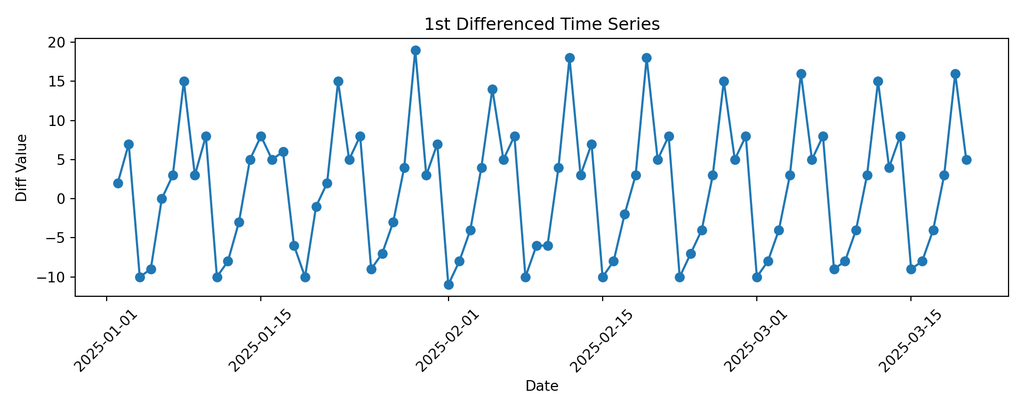

```python
plt.tight_layout()
plt.show()

# 4. 차분 후 ADF 검정
```

```python
adf_diff = adfuller(df['diff_1'].dropna())
print(f"[1차 차분 후 ADF 통계량] {adf_diff[0]:.4f}")
```

```
[1차 차분 후 ADF 통계량] -3.4114
```

```python
print(f"[1차 차분 후 ADF p-value] {adf_diff[1]:.4f}")
```

```
[1차 차분 후 ADF p-value] 0.0106
```

### 📊 R 코드

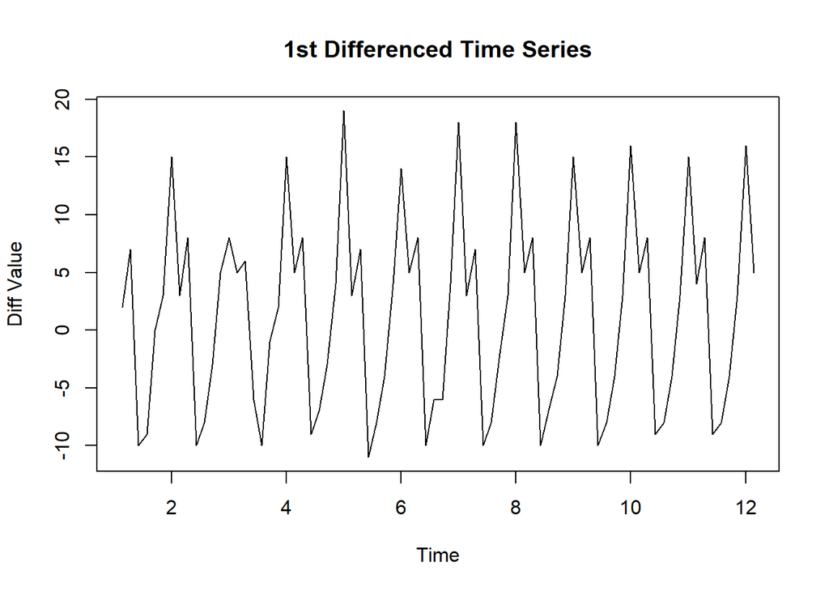

```r
# 1. 데이터 불러오기
url <- "https://raw.githubusercontent.com/MOON001208/ADP-data-set-and-analysis/main/adp_study/data/timeseries_stationarity_daily.csv"
df <- read.csv(url)
df$date <- as.Date(df$date)
df <- df[order(df$date), ]

# 2. 시계열 생성 및 1차 차분
x <- ts(df$value, frequency = 7)
x_diff <- diff(x)

# 3. 차분 시계열 그래프
plot(x_diff, main = "1st Differenced Time Series", ylab = "Diff Value", xlab = "Time")
```

```r
# 4. 차분 후 ADF 검정
adf.test(x_diff)
```

```
    Augmented Dickey-Fuller Test

data:  x_diff
Dickey-Fuller = -8.4007, Lag order = 4, p-value = 0.01
alternative hypothesis: stationary
```

### 📝 [결론 해석 모범 답안 작성법]

> 1차 차분을 수행한 뒤 다시 ADF 검정을 실시한 결과 p-value가 0.05 미만으로 도출되었다. 따라서 귀무가설을 기각하며, 차분 후 시계열은 정상성을 만족한다고 판단할 수 있다. 즉 원시 시계열은 비정상이었지만 1차 차분을 통해 정상 시계열로 변환되었다.

## 4. ACF / PACF와 Ljung-Box 검정

정상성이 확보된 뒤에는 ACF와 PACF를 통해 자기상관 구조를 확인하고, 필요하면 Ljung-Box 검정으로 백색잡음 여부를 점검합니다.

- **해석 포인트:**
  - **ACF:** 자기상관이 얼마나 오래 지속되는지 확인
  - **PACF:** 중간 시차 영향을 제거한 순수 자기상관 확인
  - **Ljung-Box:** 자기상관이 남아 있는지 검정

### 🐍 Python 코드

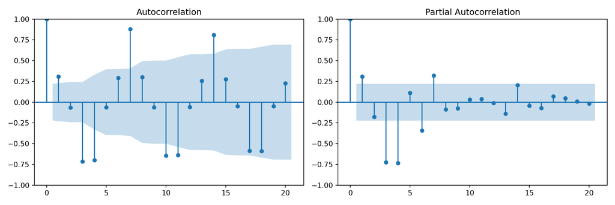

```python
import pandas as pd
import matplotlib.pyplot as plt
from statsmodels.graphics.tsaplots import plot_acf, plot_pacf
from statsmodels.stats.diagnostic import acorr_ljungbox

# 1. 데이터 불러오기
url = "https://raw.githubusercontent.com/MOON001208/ADP-data-set-and-analysis/main/adp_study/data/timeseries_stationarity_daily.csv"
df = pd.read_csv(url)
df['date'] = pd.to_datetime(df['date'])
df = df.sort_values('date')

# 2. 1차 차분
diff_1 = df['value'].diff().dropna()

# 3. ACF / PACF
fig, axes = plt.subplots(1, 2, figsize=(12, 4))
plot_acf(diff_1, ax=axes[0], lags=20)
plot_pacf(diff_1, ax=axes[1], lags=20, method='ywm')
plt.tight_layout()
plt.show()

# 4. Ljung-Box 검정
```

```python
lb = acorr_ljungbox(diff_1, lags=[10], return_df=True)
print(lb)
```

```
       lb_stat     lb_pvalue
10  213.911213  2.008011e-40
```

### 📊 R 코드

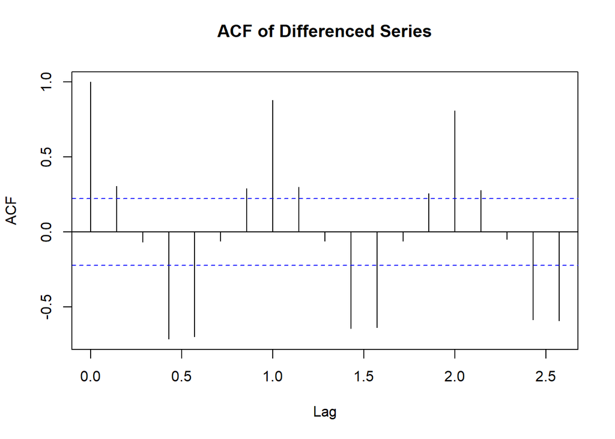

```r
# 1. 데이터 불러오기
url <- "https://raw.githubusercontent.com/MOON001208/ADP-data-set-and-analysis/main/adp_study/data/timeseries_stationarity_daily.csv"
df <- read.csv(url)
df$date <- as.Date(df$date)
df <- df[order(df$date), ]

# 2. 1차 차분
x <- ts(df$value, frequency = 7)
x_diff <- diff(x)

# 3. ACF / PACF
acf(x_diff, main = "ACF of Differenced Series")
```

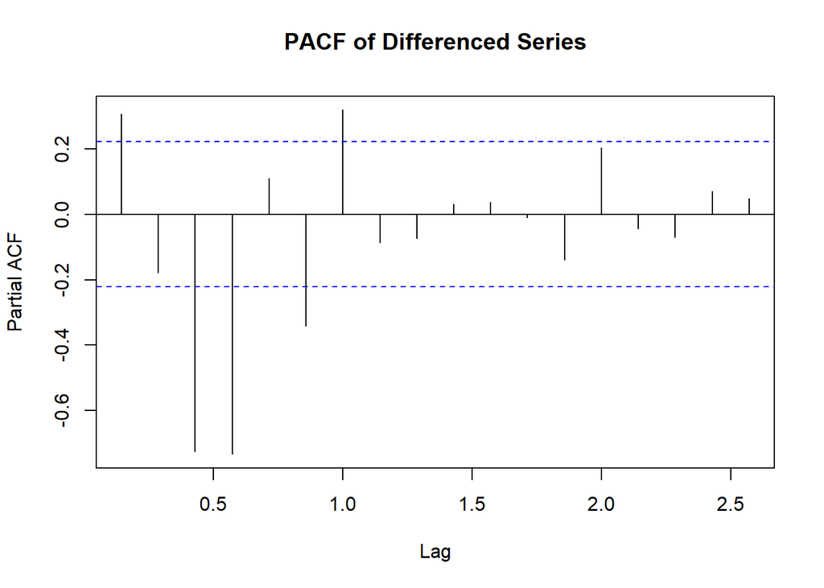

```r
pacf(x_diff, main = "PACF of Differenced Series")
```

```r
# 4. Ljung-Box 검정
Box.test(x_diff, lag = 10, type = "Ljung-Box")
```

```
    Box-Ljung test

data:  x_diff
X-squared = 213.91, df = 10, p-value < 2.2e-16
```

### 📝 [결론 해석 모범 답안 작성법]

> 1차 차분 시계열의 ACF와 PACF를 확인한 결과, 원시 시계열에서 보이던 강한 비정상 패턴은 상당 부분 제거된 것으로 보인다. 이어서 Ljung-Box 검정을 수행하여 잔존 자기상관 여부를 확인할 수 있으며, p-value 해석을 통해 백색잡음에 가까운지 또는 추가 모형화가 필요한지를 판단할 수 있다.

## ⛔ ADP 출제 위원회를 울리는 감점 방지 체크리스트

1. **“ADF 검정의 귀무가설 방향을 반대로 쓰면 안 됩니다.”**
   - ADF의 귀무가설은 **비정상(단위근 존재)** 입니다.
   - p-value가 작아야 정상이라고 판단할 수 있습니다.
2. **“비정상 시계열을 발견하면 차분을 바로 떠올리세요.”**
   - 원시계열이 비정상이면 1차 차분 후 다시 ADF 검정을 수행하는 흐름이 가장 기본입니다.
3. **“ACF/PACF는 그림과 함께 해석하세요.”**
   - 숫자만 보는 것보다, 천천히 감소하는지 특정 시차에서 끊기는지를 같이 설명해야 합니다.
4. **“Ljung-Box는 자기상관이 남아 있는지 보는 검정입니다.”**
   - p-value가 작으면 백색잡음이 아니라는 뜻이므로, 추가적인 모형화가 필요할 수 있습니다.
5. **“시계열 검정은 단독으로 끝나는 문제가 아닙니다.”**
   - 검정 결과는 이후 분해, ARIMA, 예측 단계로 이어지는 출발점이므로 차분 전후 변화를 함께 정리하는 습관이 중요합니다.